# Project #2 - Personal Loan Campaign Purchase Prediction

# **Data Preparation for Modeling**

## Data Preprocessing

We completed missing value treatment, outlier detection, found no duplicate entries in the detailed EDA section above. Next, we will proceed with feature engineering and preparing our data for modeling.

#### Feature Engineering

👉 We will drop the Experience column as it perfectly correlated with Age.  
👉 We will use dummies for ZIPCode and Education columns.

```python
# dropping Experience as it is perfectly correlated with Age
data.drop(["Personal_Loan", "Experience"], axis=1)
```

|  | Age | Income | ZIPCode | Family | CCAvg | Education | Mortgage | Securities_Account | CD_Account | Online | CreditCard |
| --- | --- | --- | --- | --- | --- | --- | --- | --- | --- | --- | --- |
| 0 | 25 | 49 | 91107 | 4 | 1.6 | Undergraduate | 0 | 1 | 0 | 0 | 0 |
| 1 | 45 | 34 | 90089 | 3 | 1.5 | Undergraduate | 0 | 1 | 0 | 0 | 0 |
| 2 | 39 | 11 | 94720 | 1 | 1.0 | Undergraduate | 0 | 0 | 0 | 0 | 0 |
| 3 | 35 | 100 | 94112 | 1 | 2.7 | Graduate | 0 | 0 | 0 | 0 | 0 |
| 4 | 35 | 45 | 91330 | 4 | 1.0 | Graduate | 0 | 0 | 0 | 0 | 1 |
| ... | ... | ... | ... | ... | ... | ... | ... | ... | ... | ... | ... |
| 4995 | 29 | 40 | 92697 | 1 | 1.9 | Advanced | 0 | 0 | 0 | 1 | 0 |
| 4996 | 30 | 15 | 92037 | 4 | 0.4 | Undergraduate | 85 | 0 | 0 | 1 | 0 |
| 4997 | 63 | 24 | 93023 | 2 | 0.3 | Advanced | 0 | 0 | 0 | 0 | 0 |
| 4998 | 65 | 49 | 90034 | 3 | 0.5 | Graduate | 0 | 0 | 0 | 1 | 0 |
| 4999 | 28 | 83 | 92612 | 3 | 0.8 | Undergraduate | 0 | 0 | 0 | 1 | 1 |

5000 rows × 11 columns

```python
# checking the number of uniques in the ZipCode column
print(
    "Total number of unique values of ZIPCode: ",
    data["ZIPCode"].nunique()
)
```

```
Total number of unique values of ZIPCode:  467
```

👉 There are 467 unique Zip Codes.

```python
# we will group the Zip codes based on the first two digits to reduce the number of unique values
data["ZIPCode"] = data["ZIPCode"].astype(str)
print(
    "Number of unique values if we take first two digits of ZIPCode: ",
    data["ZIPCode"].str[0:2].nunique(),
)
data["ZIPCode"] = data["ZIPCode"].str[0:2]
```

```
Number of unique values if we take first two digits of ZIPCode:  7
```

👉 Now, we only have 7 unique Zip Codes.

```python
# we will convert all categorical features to 'category' type
cat_cols = [
    "Education",
    "Personal_Loan",
    "Securities_Account",
    "CD_Account",
    "Online",
    "CreditCard",
    "ZIPCode",
]
data[cat_cols] = data[cat_cols].astype("category")
```

👉 This makes data smaller in the memory and improves model performance

```python
# defining the explanatory (independent) and response (dependent) variables
# dropping Experience as it is perfectly correlated with Age
X = data.drop(["Personal_Loan", "Experience"], axis=1)
y = data["Personal_Loan"]

# creating dummy variables
X = pd.get_dummies(X, columns=["ZIPCode", "Education"], drop_first=True)
# specifying the datatype of the independent variables data frame
X = X.astype(float)

X.head()
```

|  | Age | Income | Family | CCAvg | Mortgage | Securities_Account | CD_Account | Online | CreditCard | ZIPCode_91 | ZIPCode_92 | ZIPCode_93 | ZIPCode_94 | ZIPCode_95 | ZIPCode_96 | Education_Graduate | Education_Undergraduate |
| --- | --- | --- | --- | --- | --- | --- | --- | --- | --- | --- | --- | --- | --- | --- | --- | --- | --- |
| 0 | 25.0 | 49.0 | 4.0 | 1.6 | 0.0 | 1.0 | 0.0 | 0.0 | 0.0 | 1.0 | 0.0 | 0.0 | 0.0 | 0.0 | 0.0 | 0.0 | 1.0 |
| 1 | 45.0 | 34.0 | 3.0 | 1.5 | 0.0 | 1.0 | 0.0 | 0.0 | 0.0 | 0.0 | 0.0 | 0.0 | 0.0 | 0.0 | 0.0 | 0.0 | 1.0 |
| 2 | 39.0 | 11.0 | 1.0 | 1.0 | 0.0 | 0.0 | 0.0 | 0.0 | 0.0 | 0.0 | 0.0 | 0.0 | 1.0 | 0.0 | 0.0 | 0.0 | 1.0 |
| 3 | 35.0 | 100.0 | 1.0 | 2.7 | 0.0 | 0.0 | 0.0 | 0.0 | 0.0 | 0.0 | 0.0 | 0.0 | 1.0 | 0.0 | 0.0 | 1.0 | 0.0 |
| 4 | 35.0 | 45.0 | 4.0 | 1.0 | 0.0 | 0.0 | 0.0 | 0.0 | 1.0 | 1.0 | 0.0 | 0.0 | 0.0 | 0.0 | 0.0 | 1.0 | 0.0 |

#### Splitting Data into Training and Testing Datasets

```python
# splitting the data in an 70:30 ratio for train and test sets
X_train, X_test, y_train, y_test = train_test_split(X, y, test_size=0.30, stratify=y, random_state=42)
# stratify ensures that the training and test sets have a similar distribution of the response variable
```

```python
print("Shape of Training set : ", X_train.shape)
print("Shape of Test set : ", X_test.shape)
print("Percentage of classes in Training set:")
print(y_train.value_counts(normalize=True))
print("Percentage of classes in Test set:")
print(y_test.value_counts(normalize=True))
```

```
Shape of Training set :  (3500, 17)
Shape of Test set :  (1500, 17)
Percentage of classes in Training set:
Personal_Loan
0    0.904
1    0.096
Name: proportion, dtype: float64
Percentage of classes in Test set:
Personal_Loan
0    0.904
1    0.096
Name: proportion, dtype: float64
```

👉 70% of the data is in the training set (3500 out of 5000 samples) and 30% in the test set (1500 out of 5000 samples).  
👉 90.4% did not accept the loan and 9.6% accepted the loan. Proportions are exactly same becuase we used 'stratify=y'.

## Model Building

### Model Evaluation Criterion

**The model can make incorrect predictions, such as**:

1. Predicting that a customer will take a personal loan, but in reality, the customer does not take the loan: **Loss of resources**
2. Predicting that a customer will not take a personal loan, but in reality, the customer was going to take the loan: **Loss of opportunity**

**Which case is more important?**

- Losing a potential customer by predicting that the customer will not take a personal loan is a **FALSE NEGATIVE**. We definitely want to avoid these cases.

**How can we reduce the False Negative?**

- Our model must maximize **Recall** to minimize false negatives. The greater the **Recall**, the higher the chances of reducing false negatives. Therefore, our model must focus on increasing **Recall**.

### Decision Tree (scikit-learn / sklearn)

👉 Create functions to calculate the confusin matrix and the and different metrics.  
👉 We will define a utility function to compile all the metrics into a single data frame and another function to visualize the confusion matrix.

```python
# defining a function to compute different metrics to check performance of a classification model built using sklearn
def model_performance_classification(model, predictors, target):
    """
    Function to compute different metrics to check classification model performance

    model: classifier
    predictors: independent variables
    target: dependent variable
    """

    # predicting using the independent variables
    pred = model.predict(predictors)

    acc = accuracy_score(target, pred)  # to compute Accuracy
    recall = recall_score(target, pred)  # to compute Recall
    precision = precision_score(target, pred)  # to compute Precision
    f1 = f1_score(target, pred)  # to compute F1-score

    # creating a dataframe of metrics
    df_perf = pd.DataFrame(
        {"Accuracy": acc, "Recall": recall, "Precision": precision, "F1": f1,},
        index=[0],
    )

    return df_perf
```

```python
def plot_confusion_matrix(model, predictors, target):
    """
    To plot the confusion_matrix with percentages

    model: classifier
    predictors: independent variables
    target: dependent variable
    """
    # Predict the target values using the provided model and predictors
    y_pred = model.predict(predictors)

    # Compute the confusion matrix comparing the true target values with the predicted values
    cm = confusion_matrix(target, y_pred)

    # Create labels for each cell in the confusion matrix with both count and percentage
    labels = np.asarray(
        [
            ["{0:0.0f}".format(item) + "\n{0:.2%}".format(item / cm.flatten().sum())]
            for item in cm.flatten()
        ]
    ).reshape(2, 2)    # reshaping to a matrix

    # Set the figure size for the plot
    plt.figure(figsize=(6, 4))

    # Plot the confusion matrix as a heatmap with the labels
    sns.heatmap(cm, annot=labels, fmt="")

    # Add a label to the y-axis
    plt.ylabel("True label")

    # Add a label to the x-axis
    plt.xlabel("Predicted label")
```

👉 We start fitting/training the model

```python
# creating an instance of the decision tree model
dtree1 = DecisionTreeClassifier(criterion="gini", random_state=42)
# random_state sets a seed value and enables reproducibility

# fitting the model to the training data
dtree1.fit(X_train, y_train)
```

```
DecisionTreeClassifier(random_state=42)
```

#### Model Evaluation

Confusion Matrix for Training Data:

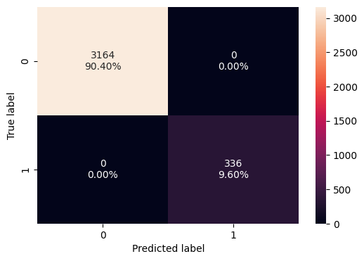

```python
plot_confusion_matrix(dtree1, X_train, y_train)
```

👉 The confusion matrix perfectly shows that there were **no instances of false negatives (Type II errors) and false positives (Type I errors)**.  
👉 Decision trees **ALWAYS** tend to overfit the training data.

```python
dtree1_train_perf = model_performance_classification(
    dtree1, X_train, y_train
)
dtree1_train_perf
```

|  | Accuracy | Recall | Precision | F1 |
| --- | --- | --- | --- | --- |
| 0 | 1.0 | 1.0 | 1.0 | 1.0 |

👉 These metrics indicate that the model performs exceptionally well, achieving perfect scores across all measures **for the training dataset**.  
👉 A decision tree **will continue to grow** and classify every single data point correctly if no restrictions are imposed, as it will learn all the patterns in the training data.

Confusion Matrix for Test Data:

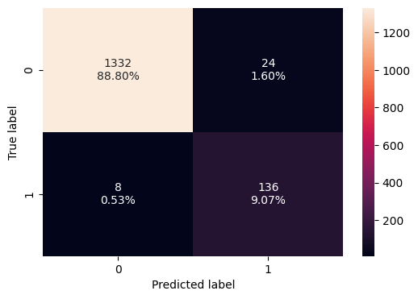

```python
plot_confusion_matrix(dtree1, X_test, y_test)
```

```python
dtree1_test_perf = model_performance_classification(
    dtree1, X_test, y_test
)
dtree1_test_perf
```

|  | Accuracy | Recall | Precision | F1 |
| --- | --- | --- | --- | --- |
| 0 | 0.978667 | 0.944444 | 0.85 | 0.894737 |

👉 While the model **performs well overall**, the recall is 0.944, which is still quite high but lower than the training data. Since our goal is to maximize Recall, this is a positive result, though there might be room for slight improvement.  
👉 While recall remains high on the test data, precision has dropped to 0.85, which indicates some false positives. This is expected when focusing on maximizing recall, as there’s often a trade-off between recall and precision.

#### Visualizing the Decision Tree

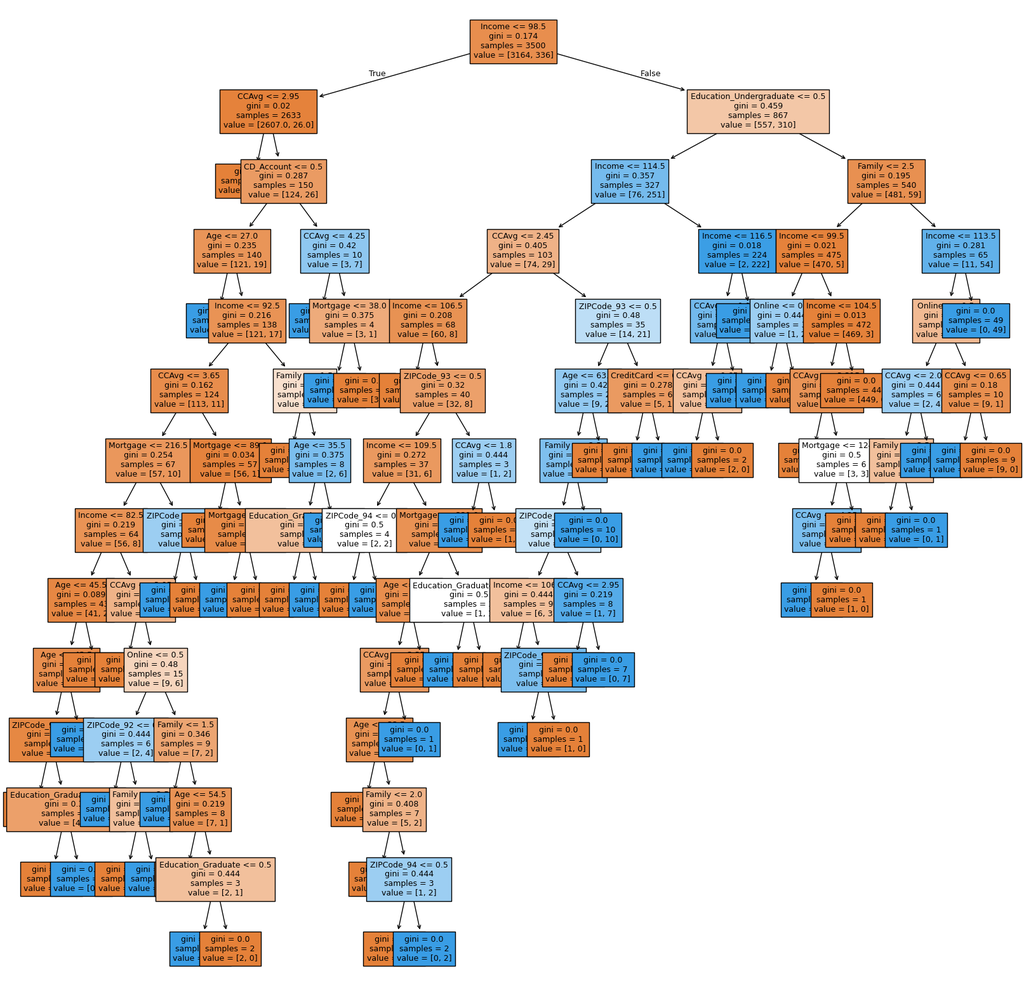

```python
# list of feature names in X_train
feature_names = list(X_train.columns)

# set the figure size for the plot
plt.figure(figsize=(20, 20))

# plotting the decision tree
out = tree.plot_tree(
    dtree1,                         # decision tree classifier model
    feature_names=feature_names,    # list of feature names (columns) in the dataset
    filled=True,                    # fill the nodes with colors based on class
    fontsize=9,                     # font size for the node text
    node_ids=False,                 # do not show the ID of each node
    class_names=None,               # whether or not to display class names
)

# add arrows to the decision tree splits if they are missing
for o in out:
    arrow = o.arrow_patch
    if arrow is not None:
        arrow.set_edgecolor("black")    # set arrow color to black
        arrow.set_linewidth(1)          # set arrow linewidth to 1

# displaying the plot
plt.show()
```

👉 This is a fully-grown decision tree. We can definitely simplify it.

```python
# printing a text report showing the rules of a decision tree
print(
    tree.export_text(
        dtree1,    # specify the model
        feature_names=feature_names,    # specify the feature names
        show_weights=True    # specify whether or not to show the weights associated with the model
    )
)
```

```
|--- Income <= 98.50
|   |--- CCAvg <= 2.95
|   |   |--- weights: [2483.00, 0.00] class: 0
|   |--- CCAvg >  2.95
|   |   |--- CD_Account <= 0.50
|   |   |   |--- Age <= 27.00
|   |   |   |   |--- weights: [0.00, 2.00] class: 1
|   |   |   |--- Age >  27.00
|   |   |   |   |--- Income <= 92.50
|   |   |   |   |   |--- CCAvg <= 3.65
|   |   |   |   |   |   |--- Mortgage <= 216.50
|   |   |   |   |   |   |   |--- Income <= 82.50
|   |   |   |   |   |   |   |   |--- Age <= 45.50
|   |   |   |   |   |   |   |   |   |--- Age <= 43.50
|   |   |   |   |   |   |   |   |   |   |--- ZIPCode_94 <= 0.50
|   |   |   |   |   |   |   |   |   |   |   |--- weights: [15.00, 0.00] class: 0
|   |   |   |   |   |   |   |   |   |   |--- ZIPCode_94 >  0.50
|   |   |   |   |   |   |   |   |   |   |   |--- truncated branch of depth 2
|   |   |   |   |   |   |   |   |   |--- Age >  43.50
|   |   |   |   |   |   |   |   |   |   |--- weights: [0.00, 1.00] class: 1
|   |   |   |   |   |   |   |   |--- Age >  45.50
|   |   |   |   |   |   |   |   |   |--- weights: [22.00, 0.00] class: 0
|   |   |   |   |   |   |   |--- Income >  82.50
|   |   |   |   |   |   |   |   |--- CCAvg <= 3.05
|   |   |   |   |   |   |   |   |   |--- weights: [6.00, 0.00] class: 0
|   |   |   |   |   |   |   |   |--- CCAvg >  3.05
|   |   |   |   |   |   |   |   |   |--- Online <= 0.50
|   |   |   |   |   |   |   |   |   |   |--- ZIPCode_92 <= 0.50
|   |   |   |   |   |   |   |   |   |   |   |--- weights: [0.00, 3.00] class: 1
|   |   |   |   |   |   |   |   |   |   |--- ZIPCode_92 >  0.50
|   |   |   |   |   |   |   |   |   |   |   |--- truncated branch of depth 2
|   |   |   |   |   |   |   |   |   |--- Online >  0.50
|   |   |   |   |   |   |   |   |   |   |--- Family <= 1.50
|   |   |   |   |   |   |   |   |   |   |   |--- weights: [0.00, 1.00] class: 1
|   |   |   |   |   |   |   |   |   |   |--- Family >  1.50
|   |   |   |   |   |   |   |   |   |   |   |--- truncated branch of depth 3
|   |   |   |   |   |   |--- Mortgage >  216.50
|   |   |   |   |   |   |   |--- ZIPCode_93 <= 0.50
|   |   |   |   |   |   |   |   |--- weights: [0.00, 2.00] class: 1
|   |   |   |   |   |   |   |--- ZIPCode_93 >  0.50
```

[output cut: 123 more lines]

```
|   |   |   |   |--- Online <= 0.50
|   |   |   |   |   |--- CCAvg <= 2.05
|   |   |   |   |   |   |--- Family <= 3.50
|   |   |   |   |   |   |   |--- weights: [2.00, 0.00] class: 0
|   |   |   |   |   |   |--- Family >  3.50
|   |   |   |   |   |   |   |--- weights: [0.00, 1.00] class: 1
|   |   |   |   |   |--- CCAvg >  2.05
|   |   |   |   |   |   |--- weights: [0.00, 3.00] class: 1
|   |   |   |   |--- Online >  0.50
|   |   |   |   |   |--- CCAvg <= 0.65
|   |   |   |   |   |   |--- weights: [0.00, 1.00] class: 1
|   |   |   |   |   |--- CCAvg >  0.65
|   |   |   |   |   |   |--- weights: [9.00, 0.00] class: 0
|   |   |   |--- Income >  113.50
|   |   |   |   |--- weights: [0.00, 49.00] class: 1
```

```python
# importance of features in the tree building

importance_df = pd.DataFrame(
    dtree1.feature_importances_, columns=["Imp"], index=X_train.columns
).sort_values(by="Imp", ascending=False)

print(importance_df)
```

```
                              Imp
Income                   0.417597
Education_Undergraduate  0.290600
Family                   0.145648
CCAvg                    0.064047
Age                      0.016731
Mortgage                 0.011947
ZIPCode_94               0.010072
CD_Account               0.009784
ZIPCode_93               0.008997
Education_Graduate       0.008670
Online                   0.008500
ZIPCode_92               0.004664
CreditCard               0.002744
Securities_Account       0.000000
ZIPCode_91               0.000000
ZIPCode_95               0.000000
ZIPCode_96               0.000000
```

## Model Performance Improvement

### Decision Tree (Pre-pruning)

Pre-pruning, also known as early stopping, involves halting the growth of a decision tree during training by setting conditions such as **maximum depth**, **minimum samples per leaf**, or **minimum impurity decrease** to prevent the model from becoming too complex and overfitting the training data.

```python
# define the parameters of the tree to iterate over
max_depth_values = np.arange(2, 7, 2)
max_leaf_nodes_values = np.arange(10, 51, 10)
min_samples_split_values = np.arange(10, 51, 10)

# initialize variables to store the best model and its performance
best_estimator = None
best_score_diff = float('inf')
best_test_score = 0.0

# iterate over all combinations of the specified parameter values
for max_depth in max_depth_values:
    for max_leaf_nodes in max_leaf_nodes_values:
        for min_samples_split in min_samples_split_values:

            # initialize the tree with the current set of parameters
            estimator = DecisionTreeClassifier(
                max_depth=max_depth,
                max_leaf_nodes=max_leaf_nodes,
                min_samples_split=min_samples_split,
                class_weight='balanced',
                random_state=42
            )

            # fit the model to the training data
            estimator.fit(X_train, y_train)

            # make predictions on the training and test sets
            y_train_pred = estimator.predict(X_train)
            y_test_pred = estimator.predict(X_test)

            # our metric is Recall !!!
            # calculate Recall scores for training and test sets
            train_recall_score = recall_score(y_train, y_train_pred)
            test_recall_score = recall_score(y_test, y_test_pred)

            # calculate the absolute difference between training and test Recall scores
            score_diff = abs(train_recall_score - test_recall_score)

            # update the best estimator and best score if the current one has a smaller score difference
            if (score_diff < best_score_diff) & (test_recall_score > best_test_score):
                best_score_diff = score_diff
                best_test_score = test_recall_score
                best_estimator = estimator
```

```python
# creating an instance of the best model
dtree2 = best_estimator

# print the best parameters
print("Best parameters found:")
print(f"Max depth: {best_estimator.max_depth}")
print(f"Max leaf nodes: {best_estimator.max_leaf_nodes}")
print(f"Min samples split: {best_estimator.min_samples_split}")
print(f"Best test Recall score: {best_test_score}")
```

```
Best parameters found:
Max depth: 2
Max leaf nodes: 10
Min samples split: 10
Best test Recall score: 1.0
```

👉 Best test Recall score of 1.0 is impressive! That means **no False Nagatives**.

```python
# fitting the best model to the training data
dtree2.fit(X_train, y_train)
```

```
DecisionTreeClassifier(class_weight='balanced', max_depth=2, max_leaf_nodes=10,
                       min_samples_split=10, random_state=42)
```

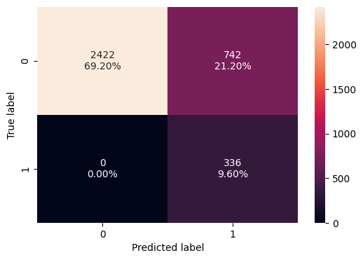

```python
plot_confusion_matrix(dtree2, X_train, y_train)
```

👉 **Training Data**: Perfect Recall, but high rate of False Positives.

```python
dtree2_train_perf = model_performance_classification(
    dtree2, X_train, y_train
)
dtree2_train_perf
```

|  | Accuracy | Recall | Precision | F1 |
| --- | --- | --- | --- | --- |
| 0 | 0.788 | 1.0 | 0.311688 | 0.475248 |

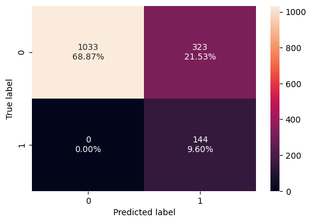

```python
plot_confusion_matrix(dtree2, X_test, y_test)
```

👉 Perfect Recall, but high rate of False Positives.  
👉 Our purpose was to maximize Recall.  
👉 This is a great model for our case!

```python
dtree2_test_perf = model_performance_classification(
    dtree2, X_test, y_test
)
dtree2_test_perf
```

|  | Accuracy | Recall | Precision | F1 |
| --- | --- | --- | --- | --- |
| 0 | 0.784667 | 1.0 | 0.308351 | 0.471358 |

👉 **Recall Improvement**: The recall reached the maximum value of 1.0 after pre-pruning, meaning the model successfully captures all positive instances.  
👉 **Trade-off**: Other performance metrics, such as precision or F1, may have declined, but this is an expected outcome given the focus on maximizing recall.  
👉 **Conclusion**: The model meets the objective of prioritizing Recall, making it suitable for our specific purpose despite a decrease in other metrics.

#### Visualize the Decision Tree one more time

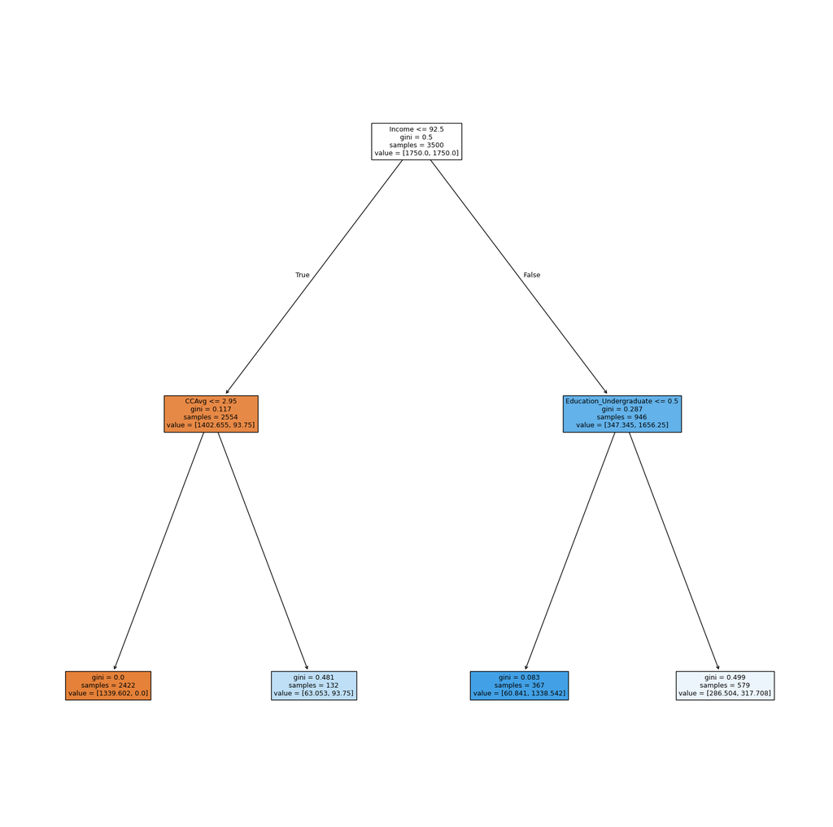

```python
# list of feature names in X_train
feature_names = list(X_train.columns)

# set the figure size for the plot
plt.figure(figsize=(20, 20))

# plotting the decision tree
out = tree.plot_tree(
    dtree2,                         # decision tree classifier model
    feature_names=feature_names,    # list of feature names (columns) in the dataset
    filled=True,                    # fill the nodes with colors based on class
    fontsize=9,                     # font size for the node text
    node_ids=False,                 # do not show the ID of each node
    class_names=None,               # whether or not to display class names
)

# add arrows to the decision tree splits if they are missing
for o in out:
    arrow = o.arrow_patch
    if arrow is not None:
        arrow.set_edgecolor("black")    # set arrow color to black
        arrow.set_linewidth(1)          # set arrow linewidth to 1

# displaying the plot
plt.show()
```

👉 The decision tree is now **much simpler** and **more readable**. The leaf values are greater than 1, indicating that each leaf represents multiple samples, suggesting **improved generalization and robustness in the model**.

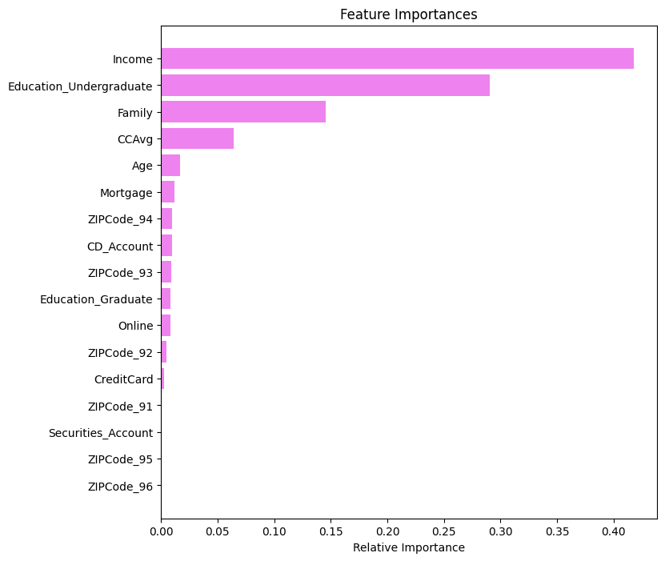

```python
importances = dtree1.feature_importances_
indices = np.argsort(importances)

plt.figure(figsize=(8, 8))
plt.title("Feature Importances")
plt.barh(range(len(indices)), importances[indices], color="violet", align="center")
plt.yticks(range(len(indices)), [feature_names[i] for i in indices])
plt.xlabel("Relative Importance")
plt.show()
```

👉 Income, Education, Family, and CCAvg are the most important features.  
👉 So, the bank should campaign more on people with higher income, more education, and larger family sizes.

## Finalizing the Model

**Comparing the default model with the pre-pruned model**:

```python
# testing performance comparison
models_test_comp_df = pd.concat(
    [
        dtree1_test_perf.T,
        dtree2_test_perf.T,
    ],
    axis=1,
)
models_test_comp_df.columns = [
    "Decision Tree (sklearn default)",
    "Decision Tree (Pre-Pruning)",
]
print("Test set performance comparison:")
models_test_comp_df
```

```
Test set performance comparison:
```

|  | Decision Tree (sklearn default) | Decision Tree (Pre-Pruning) |
| --- | --- | --- |
| Accuracy | 0.978667 | 0.784667 |
| Recall | 0.944444 | 1.000000 |
| Precision | 0.850000 | 0.308351 |
| F1 | 0.894737 | 0.471358 |

**Accuracy**: The default decision tree has higher accuracy (0.978) compared to the pre-pruned model (0.785). This indicates that the default tree classifies more instances correctly overall, but it might be overfitting the training data.

**Recall**: The pre-pruned model achieves perfect recall (1.0), meaning it correctly identifies all positive cases. **This aligns with our goal to maximize recall, although other metrics are compromised**.

**Precision**: The default decision tree has much higher precision (0.85) compared to the pre-pruned version (0.308). This suggests the pre-pruned model is more prone to false positives, as it predicts more positives but with less accuracy.

**F1 Score**: The F1 score, which balances precision and recall, is higher for the default model (0.895) than for the pre-pruned model (0.471). The pre-pruned model sacrifices balance to maximize recall.

In conclusion, while pre-pruning maximizes recall, it significantly lowers precision and overall accuracy. The trade-off here is between identifying all positive cases versus having more false positives.

### Prediction time on a single data point

```python
%%time
# choosing a data point
applicant_details = X_test.iloc[:1, :]

# making a prediction
approval_prediction = dtree2.predict(applicant_details)

print(approval_prediction)
```

```
[0]
CPU times: user 5.28 ms, sys: 0 ns, total: 5.28 ms
Wall time: 5.08 ms
```

👉 The model was able to predict the approval status in under 6 milliseconds. It indicates that the **model makes predictions very quickly and efficiently**.

## Actionable Insights and Business Recommendations

👉 The AllLife bank can deploy **this Machine Learning model** for the initial screening of personal loan applications.  
👉 The model can be used to target high-potential liability customers for personalized marketing campaigns.  
👉 It allows the bank to focus resources on customers with the highest probability of converting to personal loans.  
👉 The model helps identify key customer attributes that influence loan purchases, guiding tailored product offerings.  
👉 The model's **fast prediction time makes it suitable for real-time marketing or automated decision-making systems**.